# PCA and Clustering (optimal multiple testing)

Hajin Jang

12/9/2025

## Hierarchical clustering

#### Data

```r
library(ISLR2)
data("USArrests")

str(USArrests)
```

```
## 'data.frame':    50 obs. of  4 variables:
##  $ Murder  : num  13.2 10 8.1 8.8 9 7.9 3.3 5.9 15.4 17.4 ...
##  $ Assault : int  236 263 294 190 276 204 110 238 335 211 ...
##  $ UrbanPop: int  58 48 80 50 91 78 77 72 80 60 ...
##  $ Rape    : num  21.2 44.5 31 19.5 40.6 38.7 11.1 15.8 31.9 25.8 ...
```

```r
summary(USArrests)
```

```
##      Murder          Assault         UrbanPop          Rape
##  Min.   : 0.800   Min.   : 45.0   Min.   :32.00   Min.   : 7.30
##  1st Qu.: 4.075   1st Qu.:109.0   1st Qu.:54.50   1st Qu.:15.07
##  Median : 7.250   Median :159.0   Median :66.00   Median :20.10
##  Mean   : 7.788   Mean   :170.8   Mean   :65.54   Mean   :21.23
##  3rd Qu.:11.250   3rd Qu.:249.0   3rd Qu.:77.75   3rd Qu.:26.18
##  Max.   :17.400   Max.   :337.0   Max.   :91.00   Max.   :46.00
```

```r
apply(USArrests,2,sd)
```

```
##    Murder   Assault  UrbanPop      Rape
##  4.355510 83.337661 14.474763  9.366385
```

#### Hierarchical clustering with complete linkage and Euclidean distance

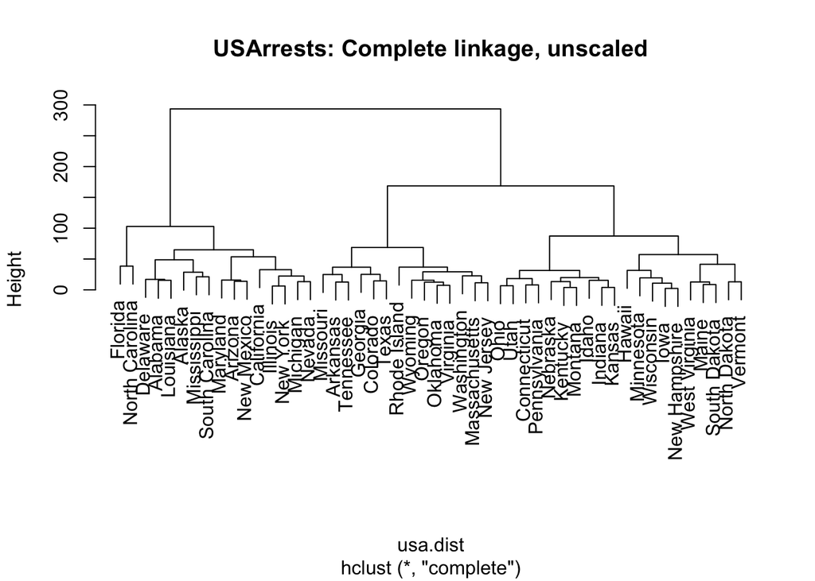

```r
# Distance matrix using Euclidean distance
usa.dist <- dist(USArrests)

# Hierarchical clustering with complete linkage
hc.complete <- hclust(usa.dist, method = "complete")

# Dendrogram
plot(hc.complete, main = "USArrests: Complete linkage, unscaled")
```

#### Cutting the dendrogram (3-distinct clusters)

```r
# Cut tree to obtain 3 clusters
hc3 <- cutree(hc.complete, k = 3)

# Cluster membership
hc3
```

```
##        Alabama         Alaska        Arizona       Arkansas     California
##              1              1              1              2              1
##       Colorado    Connecticut       Delaware        Florida        Georgia
##              2              3              1              1              2
##         Hawaii          Idaho       Illinois        Indiana           Iowa
##              3              3              1              3              3
##         Kansas       Kentucky      Louisiana          Maine       Maryland
##              3              3              1              3              1
##  Massachusetts       Michigan      Minnesota    Mississippi       Missouri
##              2              1              3              1              2
##        Montana       Nebraska         Nevada  New Hampshire     New Jersey
##              3              3              1              3              2
##     New Mexico       New York North Carolina   North Dakota           Ohio
##              1              1              1              3              3
##       Oklahoma         Oregon   Pennsylvania   Rhode Island South Carolina
##              2              2              3              2              1
##   South Dakota      Tennessee          Texas           Utah        Vermont
##              3              2              2              3              3
##       Virginia     Washington  West Virginia      Wisconsin        Wyoming
##              2              2              3              3              2
```

```r
# Size of each cluster
table(hc3)
```

```
## hc3
##  1  2  3
## 16 14 20
```

```r
# Summarize the original variables by cluster
cluster.summary <- aggregate(USArrests, by = list(cluster = hc3), FUN = mean)
cluster.summary
```

```
##   cluster    Murder  Assault UrbanPop     Rape
## 1       1 11.812500 272.5625 68.31250 28.37500
## 2       2  8.214286 173.2857 70.64286 22.84286
## 3       3  4.270000  87.5500 59.75000 14.39000
```

**Comment:** After cutting the dendrogram to obtain three clusters, we observed a separation of the states based on the levels of violent crime rates. The resulting cluster membership was as follows: Cluster 1 = 16 states, Cluster 2 = 14 states, and Cluster 3 = 20 states.

Cluster 1 shows the highest overall crime rates among the three groups. The average Murder (11.81), Assault (272.56), and Rape (28.38) values are substantially higher than those of the other clusters. UrbanPop is moderately high (68.31). Overall, states in Cluster 1 represent high-crime states with elevated levels across all violent crime indicators.

Cluster 2 represents a moderate-crime group. The mean values for Murder (8.21), Assault (173.29), and Rape (22.84) are consistently lower than Cluster 1 but higher than Cluster 3. UrbanPop is highest here (70.64), suggesting that these states tend to be more urban but do not necessarily exhibit the highest crime rates. Thus, Cluster 2 reflects states with intermediate violent crime rates and relatively higher urban populations.

Cluster 3 contains states with the lowest crime levels. The average Murder rate was 4.27, Assault 87.55, and Rape 14.39, all substantially lower than in the other clusters. UrbanPop is also lower (59.75), indicating that these states tend to be less urbanized. Cluster 3 therefore represents low-crime, more rural states.

#### c. Hierarchical clustering, after scaling

```r
# Scale variables to have sd = 1
usa.scaled <- scale(USArrests, center = FALSE, scale = TRUE)

# Check sd = 1
apply(usa.scaled, 2, sd)
```

```
##    Murder   Assault  UrbanPop      Rape
## 0.4843606 0.4350236 0.2135889 0.4002118
```

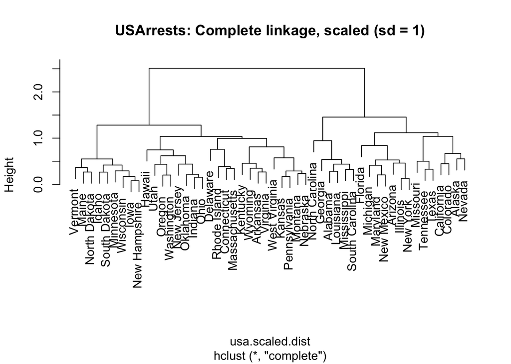

```r
# Distance matrix and hierarchical clustering on scaled data
usa.scaled.dist <- dist(usa.scaled)
hc.complete.sd  <- hclust(usa.scaled.dist, method = "complete")

plot(hc.complete.sd, main = "USArrests: Complete linkage, scaled (sd = 1)")
```

**Comment:** Scaling the variables has a substantial effect on the hierarchical clustering results. In the original dataset, the variables have very different scales and variances (e.g., Assault has a much larger variance than other variables). Without scaling, variables with larger spread dominate the Euclidean distance calculation, causing the clustering solution to primarily reflect those high-variance variables.

In my opinion, the variables should be scaled before computing inter-observation dissimilarities in this setting. Because hierarchical clustering relies directly on Euclidean distance, differences in scale can bias the distance measure and produce misleading clusters. Scaling prevents any one variable from dominating the analysis and ensures that the clustering structure reflects the combined patterns across all variables.

#### PCA (scale and center)

```r
# PCA with centering and scaling
usa.pca <- prcomp(USArrests, center = TRUE, scale = TRUE)
summary(usa.pca)
```

```
## Importance of components:
##                           PC1    PC2     PC3     PC4
## Standard deviation     1.5749 0.9949 0.59713 0.41645
## Proportion of Variance 0.6201 0.2474 0.08914 0.04336
## Cumulative Proportion  0.6201 0.8675 0.95664 1.00000
```

```r
# Proportion and cumulative proportion of variance explained
usa.pca$importance <- summary(usa.pca)$importance
usa.pca$importance
```

```
##                             PC1       PC2       PC3       PC4
## Standard deviation     1.574878 0.9948694 0.5971291 0.4164494
## Proportion of Variance 0.620060 0.2474400 0.0891400 0.0433600
## Cumulative Proportion  0.620060 0.8675000 0.9566400 1.0000000
```

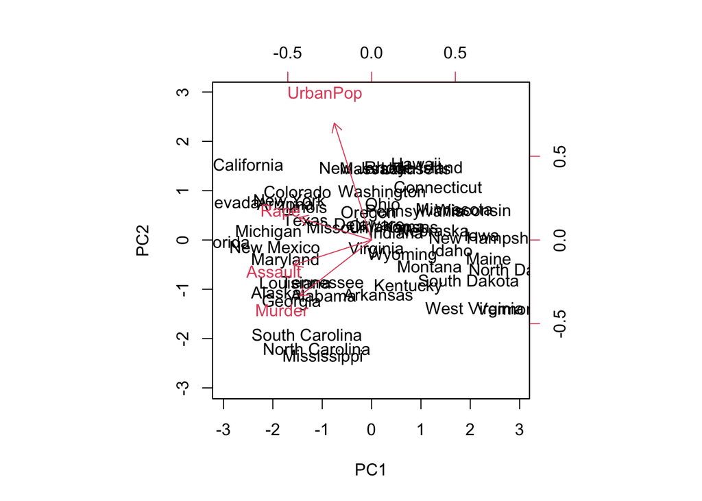

```r
biplot(usa.pca, scale=0)
```

```r
# Factor loadings (all components)
usa.pca$rotation
```

```
##                 PC1        PC2        PC3         PC4
## Murder   -0.5358995 -0.4181809  0.3412327  0.64922780
## Assault  -0.5831836 -0.1879856  0.2681484 -0.74340748
## UrbanPop -0.2781909  0.8728062  0.3780158  0.13387773
## Rape     -0.5434321  0.1673186 -0.8177779  0.08902432
```

**Comment:** From the PCA output, PC1 + PC2 explain 0.62006 + 0.24744 = 0.86750 (86.75%). Therefore, the first two principal components are sufficient to explain more than 75% of the total variation in the data.

#### Hierarchical clustering on the PCs

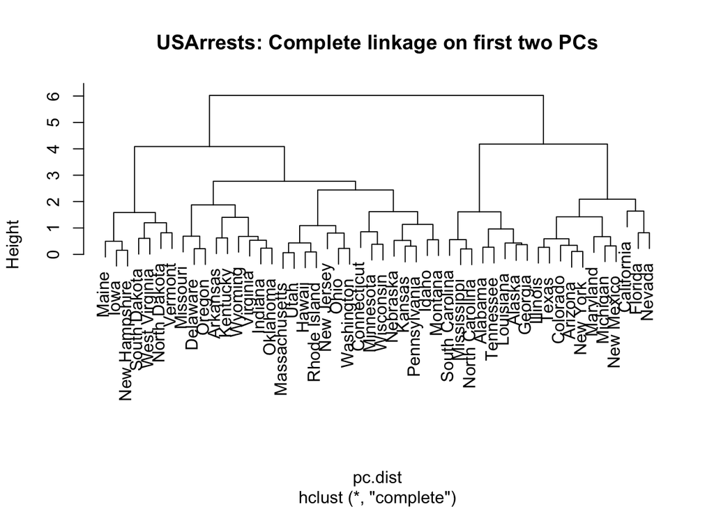

```r
# Take the first 2 principal component scores
pc.scores <- usa.pca$x[, 1:2]

# Distance matrix
pc.dist <- dist(pc.scores)
hc.pc.comp <- hclust(pc.dist, method = "complete")

plot(hc.pc.comp, main = "USArrests: Complete linkage on first two PCs")
```

```r
# Cut to 3 clusters
pc.hc3 <- cutree(hc.pc.comp, k = 3)
table(pc.hc3)
```

```
## pc.hc3
##  1  2  3
##  8 11 31
```

```r
# Summarize original variables by PC based clusters
pc.cluster.summary <- aggregate(USArrests, by = list(cluster = pc.hc3), FUN = mean)
pc.cluster.summary
```

```
##   cluster    Murder  Assault UrbanPop     Rape
## 1       1 14.087500 252.7500 53.50000 24.53750
## 2       2 11.054545 264.0909 79.09091 32.61818
## 3       3  5.003226 116.4839 63.83871 16.33871
```

**Comment:** Hierarchical clustering was performed using the first two principal component scores, which together capture 86.75% of the total variation in the dataset. The resulting dendrogram shows three clear groups when cut at k=3, with cluster sizes of 8, 11, and 31 states.

Summarizing the original variables within each PC-based cluster shows distinct crime and demographic profiles. Cluster 2 represents the highest crime, most urban group: it has the highest mean Assault rate (about 264 per 100,000), the highest Rape rate (about 32.6), and the highest UrbanPop (about 79 percent), with a moderately high Murder rate (about 11.1). Cluster 1 is also a high crime group but with a slightly different profile: it has the highest mean Murder rate (about 14.1) and a high Assault rate (about 252.8), but lowest UrbanPop (about 53.5) and somewhat lower Rape (about 24.5) than cluster 2, suggesting less urban states with particularly elevated homicide. Cluster 3 contains the majority of states and corresponds to a relatively low crime group: it has by far the lowest Murder (about 5.0) and Assault (about 116.5) rates and the lowest Rape rate (about 16.3), with an intermediate level of UrbanPop (about 63.8). Overall, clustering the states in the space defined by the first two principal components organizes them primarily along gradients of overall violent crime level and urbanization, separating high homicide states, highly urban high assault and rape states, and a large group of relatively low crime states.